# Microbiome analysis of Germany and Sweden

Talia_Karasov

5/3/2019

# Load vs. microbiome composition

This script explores the relationship between load and microbiome for the german and swedish datasets and graphs the microbiomes of these datasets

### Filtering

First thing is to remove the offending columns from the german dataset and then to combine the metagenome files. These tasks are done with the clean_tables script:

```r
source("~/Dropbox/controlled_metagenomics/scripts/keep_used_in_publication/clean_tables.R")
```

### Analysis

#### Overall Comparison of Composition

The goal of this next part is to generate figures side-by-side that will take the metagenome corrected tables for germany and sweden and graph the bar plots next to one another

OK, now we never have to deal with filtering again. Now we want to generate the side by side histograms of loads

```
## [1] "German Bacteria"
```

```
## # A tibble: 9 x 2
##   Family               mean
##   <fct>               <dbl>
## 1 Enterobacteriaceae 0.0138
## 2 Burkholderiaceae   0.0622
## 3 Microbacteriaceae  0.0750
## 4 Hymenobacteraceae  0.0779
## 5 Comamonadaceae     0.106
## 6 Oscillatoriaceae   0.198
## 7 Sphingomonadaceae  0.203
## 8 Pseudomonadaceae   0.726
## 9 Other              0.910
```

```
## [1] "Swedish Bacteria"
```

```
## # A tibble: 9 x 2
##   Family                mean
##   <chr>                <dbl>
## 1 Oscillatoriaceae   0.00108
## 2 Comamonadaceae     0.0194
## 3 Hymenobacteraceae  0.0315
## 4 Microbacteriaceae  0.0391
## 5 Enterobacteriaceae 0.0642
## 6 Sphingomonadaceae  0.0776
## 7 Other              0.286
## 8 Pseudomonadaceae   0.298
## 9 Burkholderiaceae   0.412
```

```
## [1] "German Fungi"
```

```
## # A tibble: 7 x 2
##   Family                 mean
##   <fct>                 <dbl>
## 1 Debaryomycetaceae  0.000403
## 2 Aspergillaceae     0.000528
## 3 Saccharomycetaceae 0.000571
## 4 Ustilaginaceae     0.000619
## 5 Pleosporaceae      0.00133
## 6 Ceratobasidiaceae  0.00134
## 7 Other              0.00799
```

```
## [1] "Swedish Fungi"
```

```
## # A tibble: 7 x 2
##   Family                  mean
##   <chr>                  <dbl>
## 1 Ceratobasidiaceae  0.0000163
## 2 Aspergillaceae     0.000301
## 3 Debaryomycetaceae  0.000304
## 4 Ustilaginaceae     0.000421
## 5 Saccharomycetaceae 0.000435
## 6 Pleosporaceae      0.000630
## 7 Other              0.00431
```

```
## [1] "German Oomycetes"
```

```
## # A tibble: 6 x 2
##   Family              mean
##   <fct>              <dbl>
## 1 Other           5.76e-14
## 2 Lagenidiaceae   5.48e- 8
## 3 Pythiaceae      1.35e- 5
## 4 Saprolegniaceae 1.73e- 4
## 5 Albuginaceae    6.78e- 4
## 6 Peronosporaceae 4.26e- 3
```

```
## [1] "Swedish Oomycetes"
```

```
## # A tibble: 6 x 2
##   Family              mean
##   <chr>              <dbl>
## 1 Other           7.45e-13
## 2 Lagenidiaceae   5.94e- 7
## 3 Pythiaceae      1.84e- 4
## 4 Saprolegniaceae 3.70e- 4
## 5 Albuginaceae    7.58e- 3
## 6 Peronosporaceae 8.76e- 2
```

The average load of bacteria is:

```
##       mean       sd
## 1 2.135211 2.854939
```

The average load of fungi is:

```
##         mean         sd
## 1 0.01146404 0.01169445
```

The average load of oomycete is:

```
##         mean        sd
## 1 0.02390322 0.1265973
```

These are the side-by-side histogram plots

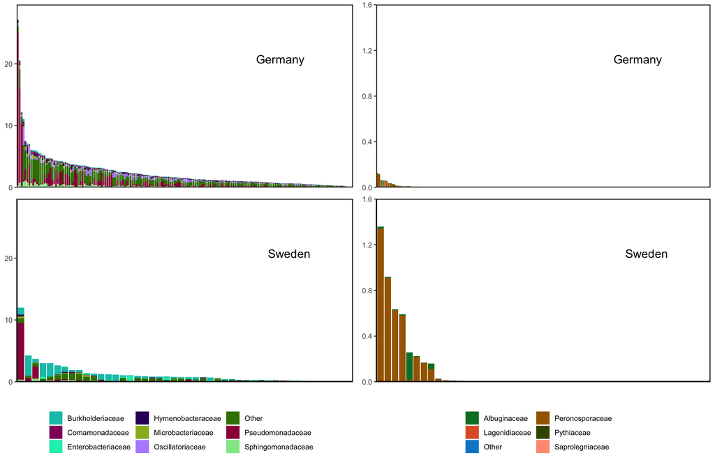